# Assignment1_Chitrank_Dave

## Assignment 1

Imports

```python
import pandas as pd
import matplotlib.pyplot as plt
import seaborn as sns

from sklearn.svm import SVC
from sklearn.model_selection import train_test_split, GridSearchCV
from sklearn.preprocessing import StandardScaler
from sklearn.metrics import accuracy_score ,recall_score , precision_score , f1_score , classification_report , confusion_matrix
```

```python
bc_df = pd.read_csv('../../practical_labs/datasets/breast_cancer.csv')
```

```python
bc_df['diagnosis'].value_counts()
```

```
diagnosis
B    357
M    212
Name: count, dtype: int64
```

```python
bc_df.head()
```

|  | id | diagnosis | radius_mean | texture_mean | perimeter_mean | area_mean | smoothness_mean | compactness_mean | concavity_mean | concave points_mean | ... | radius_worst | texture_worst | perimeter_worst | area_worst | smoothness_worst | compactness_worst | concavity_worst | concave points_worst | symmetry_worst | fractal_dimension_worst |
| --- | --- | --- | --- | --- | --- | --- | --- | --- | --- | --- | --- | --- | --- | --- | --- | --- | --- | --- | --- | --- | --- |
| 0 | 842302 | M | 17.99 | 10.38 | 122.80 | 1001.0 | 0.11840 | 0.27760 | 0.3001 | 0.14710 | ... | 25.38 | 17.33 | 184.60 | 2019.0 | 0.1622 | 0.6656 | 0.7119 | 0.2654 | 0.4601 | 0.11890 |
| 1 | 842517 | M | 20.57 | 17.77 | 132.90 | 1326.0 | 0.08474 | 0.07864 | 0.0869 | 0.07017 | ... | 24.99 | 23.41 | 158.80 | 1956.0 | 0.1238 | 0.1866 | 0.2416 | 0.1860 | 0.2750 | 0.08902 |
| 2 | 84300903 | M | 19.69 | 21.25 | 130.00 | 1203.0 | 0.10960 | 0.15990 | 0.1974 | 0.12790 | ... | 23.57 | 25.53 | 152.50 | 1709.0 | 0.1444 | 0.4245 | 0.4504 | 0.2430 | 0.3613 | 0.08758 |
| 3 | 84348301 | M | 11.42 | 20.38 | 77.58 | 386.1 | 0.14250 | 0.28390 | 0.2414 | 0.10520 | ... | 14.91 | 26.50 | 98.87 | 567.7 | 0.2098 | 0.8663 | 0.6869 | 0.2575 | 0.6638 | 0.17300 |
| 4 | 84358402 | M | 20.29 | 14.34 | 135.10 | 1297.0 | 0.10030 | 0.13280 | 0.1980 | 0.10430 | ... | 22.54 | 16.67 | 152.20 | 1575.0 | 0.1374 | 0.2050 | 0.4000 | 0.1625 | 0.2364 | 0.07678 |

5 rows × 32 columns

```python
bc_df.info()
```

```
<class 'pandas.core.frame.DataFrame'>
RangeIndex: 569 entries, 0 to 568
Data columns (total 32 columns):
 #   Column                   Non-Null Count  Dtype
---  ------                   --------------  -----
 0   id                       569 non-null    int64
 1   diagnosis                569 non-null    object
 2   radius_mean              569 non-null    float64
 3   texture_mean             569 non-null    float64
 4   perimeter_mean           569 non-null    float64
 5   area_mean                569 non-null    float64
 6   smoothness_mean          569 non-null    float64
 7   compactness_mean         569 non-null    float64
 8   concavity_mean           569 non-null    float64
 9   concave points_mean      569 non-null    float64
```

[output cut: 24 more lines]

##### Descriptive Analytics Tasks

##### 1. Analyze the correlation between all the numerical features

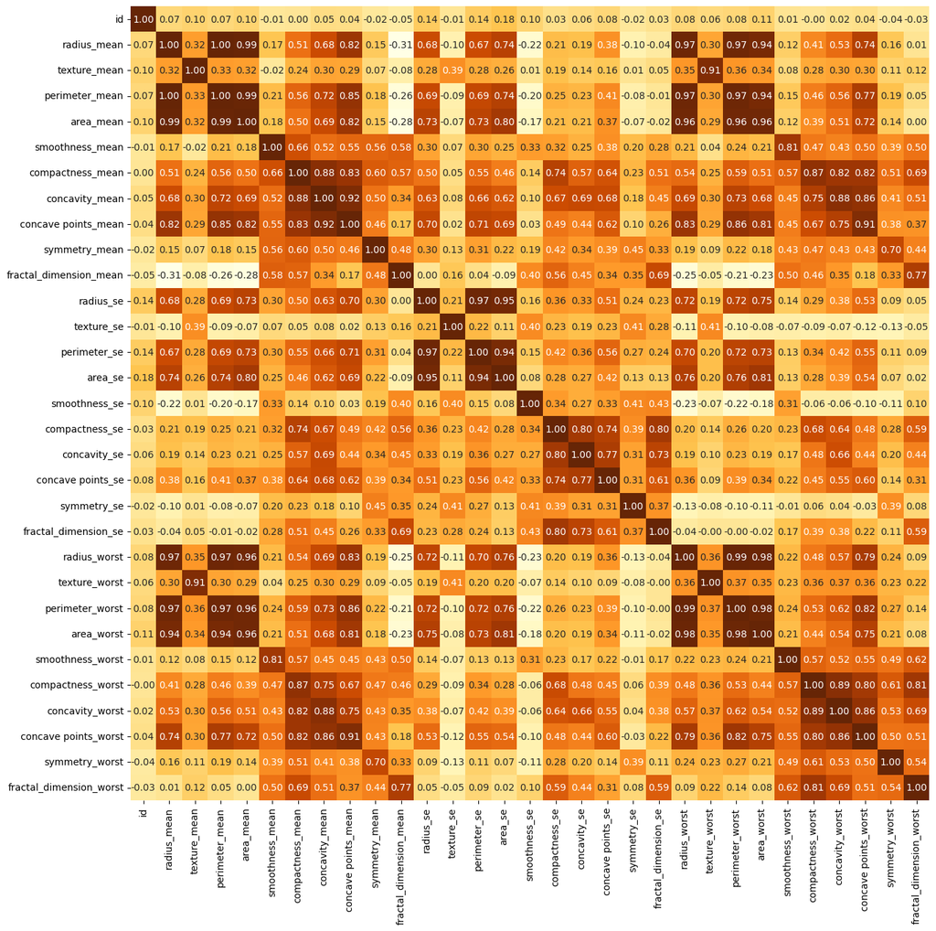

```python
data_corr = bc_df.select_dtypes(include=['int', 'float']).corr()

plt.figure(figsize=[15,15])
sns.heatmap(data_corr, cmap='YlOrBr',annot=True, cbar=False,fmt=".2f")
```

#### ML Model Training and Testing Tasks

```python
X = bc_df.drop('diagnosis', axis = 1)
y = bc_df['diagnosis']
```

- 1. Split the data into training and testing sets

```python
X_train, X_test, y_train, y_test = train_test_split(X, y, test_size=0.2, random_state=42)
```

```python
scaler = StandardScaler()
```

```python
X_train_scaled = scaler.fit_transform(X_train)
X_test_scaled = scaler.transform(X_test)
```

- 2. Utilize the class weights approach to handle class imbalance in the following model training code.

```python
svm = SVC(class_weight='balanced')
```

- 3. Train the SVC model on the training set, however you need to do a comparison between the performance of the model on the validation set using different hyperparameter values

```python
param_grid = {
    'C': [0.05, 0.5, 5, 500, 5000],
    'kernel': ['linear', 'poly', 'rbf', 'sigmoid'],
    'degree': [2, 3]
}
```

```python
grid_search = GridSearchCV(estimator=svm, param_grid=param_grid, cv =10, scoring='accuracy' , verbose=5)
grid_search.fit(X_train_scaled, y_train)
```

[output not shown]

[output cut: 346 more lines]

[output not shown]

```
GridSearchCV(cv=10, estimator=SVC(class_weight='balanced'),
             param_grid={'C': [0.05, 0.5, 5, 500, 5000], 'degree': [2, 3],
                         'kernel': ['linear', 'poly', 'rbf', 'sigmoid']},
             scoring='accuracy', verbose=5)
```

- 4. Based on the explanations discussed in class, provide an elaborate comment and explanation on the top performing combination of hyperparameters.

```python
grid_search.best_params_
```

```
{'C': 0.05, 'degree': 2, 'kernel': 'linear'}
```

##### Top-Performing Hyperparameters

The top-performing combination of hyperparameters is as follows:

- **Regularization parameter 'C':** 0.05
  - The regularization parameter `C` in the SVM model controls the trade-off between maximized margin and minimum misclassifed points.
  - `C=0.05` -> priortize maximum margin and more misclassifed points
  - A value of `C=0.05` suggests a moderate regularization strength, aiming to find a balance between fitting the training data well and generalizing to new, unseen data.
- **Kernel type: Linear**
  - The Linear kernel is chosen, implying that the decision boundary will be a linear function of the input features.
- **Degree of the polynomial kernel: 2**
  - In this case, the 'linear' kernel is chosen, therefore the `degree parameter is not relevant`.

Overall, with `C=0.05`, `linear kernel`, and `degree=2`, the model is configured to find a moderate decision boundary, capturing linear patterns in the data.

- 5. Evaluate the top performing model's performance on the test set using the following metrics

Using the best prefroming model

```python
best_model  = grid_search.best_estimator_
```

```python
best_model.fit(X_train_scaled,y_train)
```

```
SVC(C=0.05, class_weight='balanced', degree=2, kernel='linear')
```

Making Predictions

```python
y_pred = best_model.predict(X_test_scaled)
```

Evaluating the model using:

- Accuracy
- Precision
- Recall
- F1 score

```python
accuracy = accuracy_score(y_test, y_pred)
precision = precision_score(y_test, y_pred, average='weighted')
recall = recall_score(y_test, y_pred, average='weighted')
f1 = f1_score(y_test, y_pred, average='weighted')

print("Test set recall: {:.4f}".format(recall))
print("Test set F1-score: {:.4f}".format(f1))
print("Test set accuracy: {:.4f}".format(accuracy))
print("Test set precision: {:.4f}".format(precision))
```

[output not shown]

```python
print(classification_report(y_test, y_pred))
```

```
              precision    recall  f1-score   support

           B       0.97      0.99      0.98        71
           M       0.98      0.95      0.96        43

    accuracy                           0.97       114
   macro avg       0.97      0.97      0.97       114
weighted avg       0.97      0.97      0.97       114
```

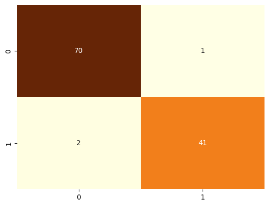

```python
sns.heatmap(confusion_matrix(y_test, y_pred),cmap='YlOrBr', annot=True , cbar=False)
```

The model is performing `very good` as the accuracy, recall , precision and f1 score is very high.